# R Notebook

## Normality after Transformation Non Winsorized

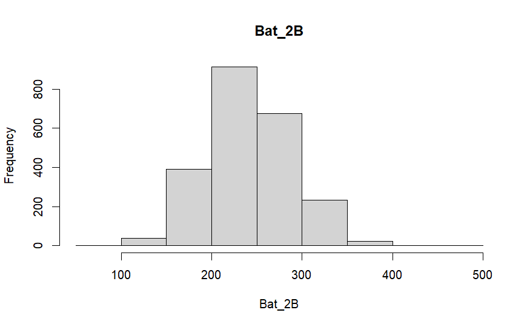

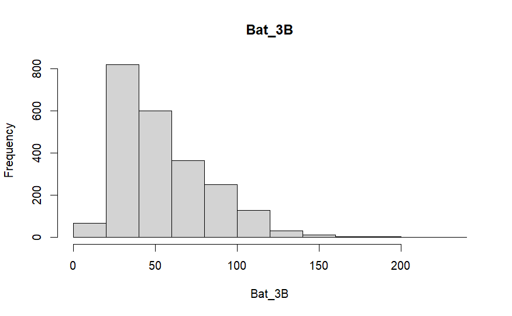

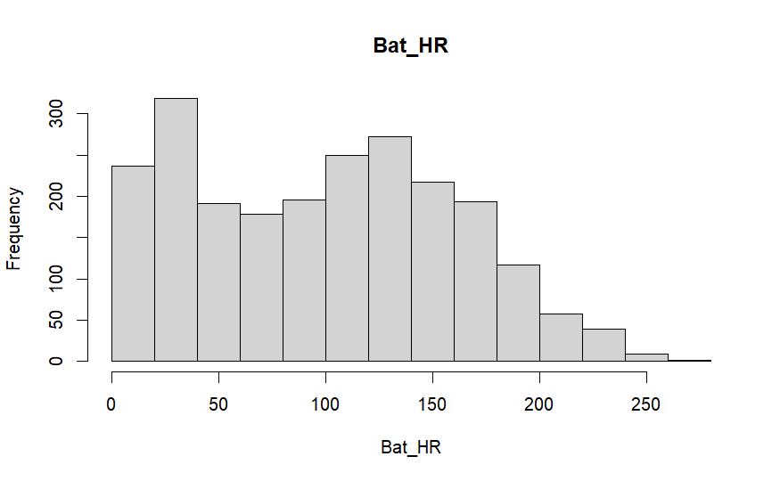

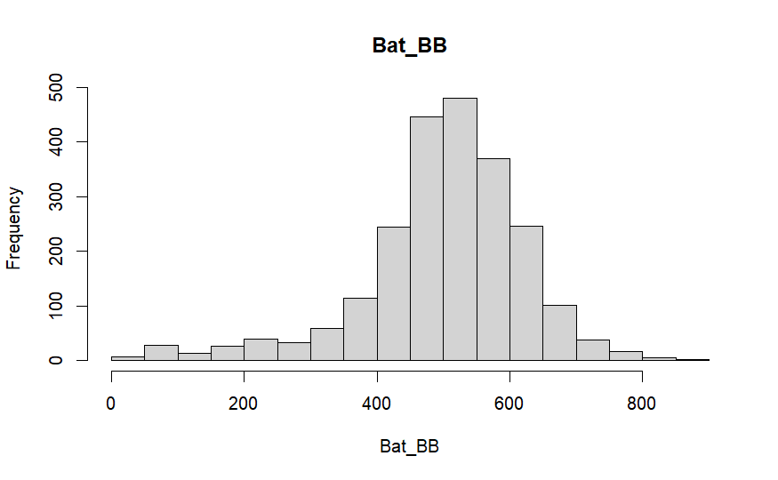

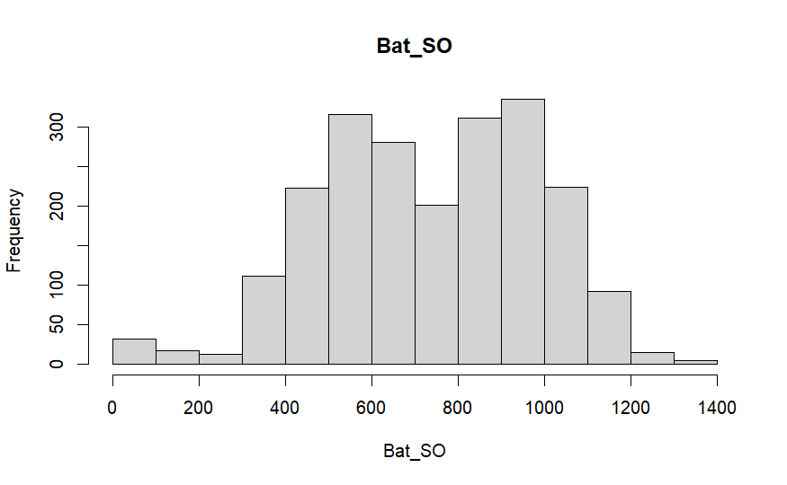

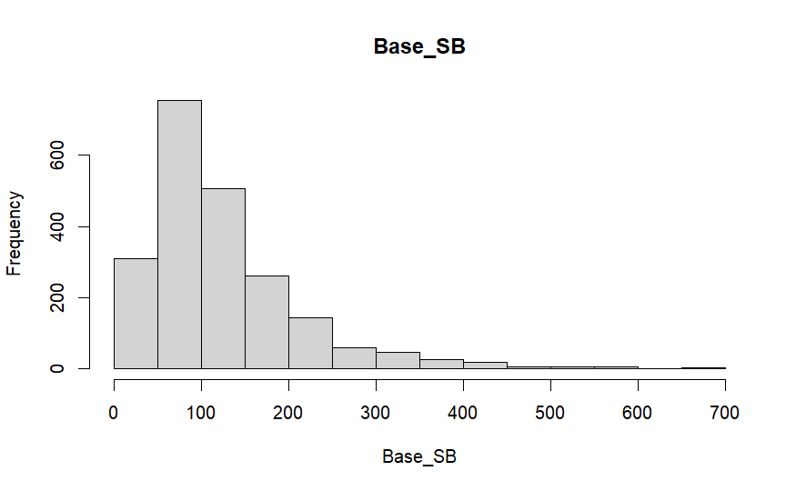

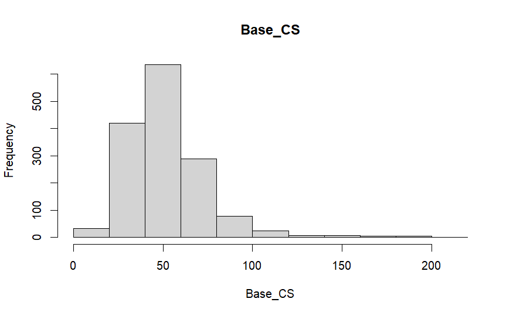

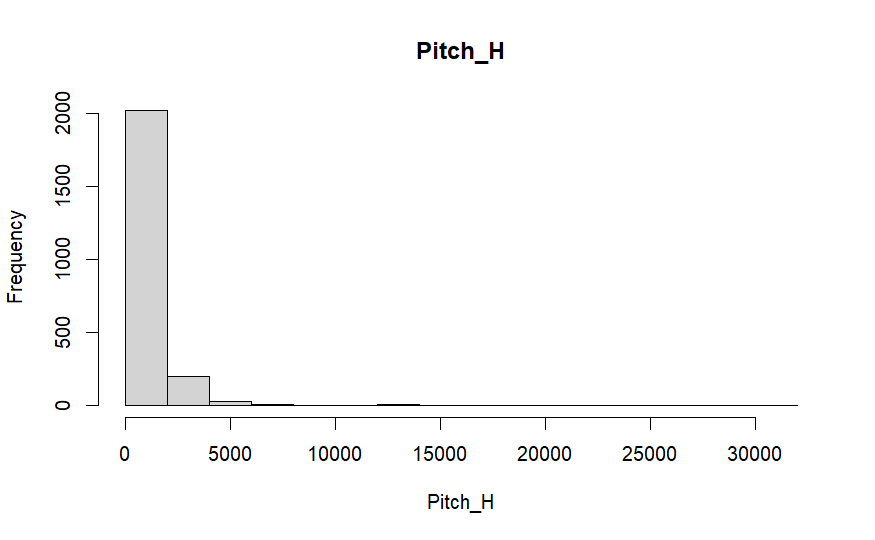

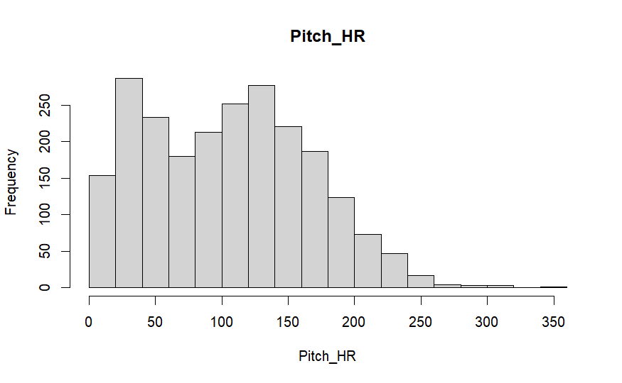

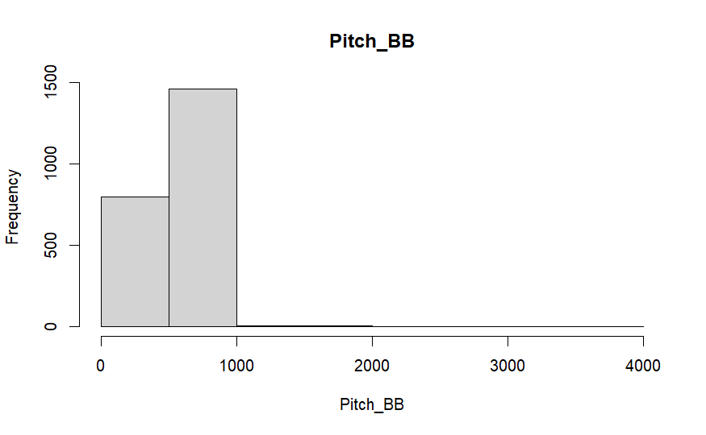

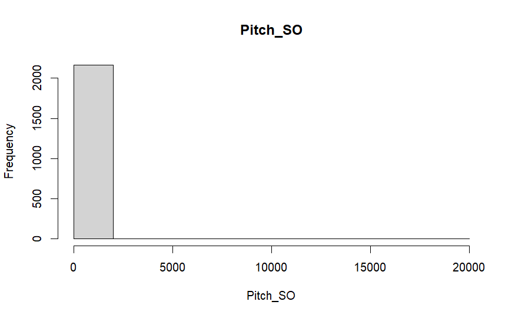

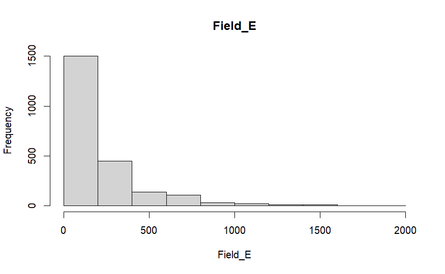

[1 more figures not shown]

```r
for (col_name in colnames(trainBC[-1])) {
  hist(train_cleaned[[col_name]], main = col_name, xlab = col_name)
}
```

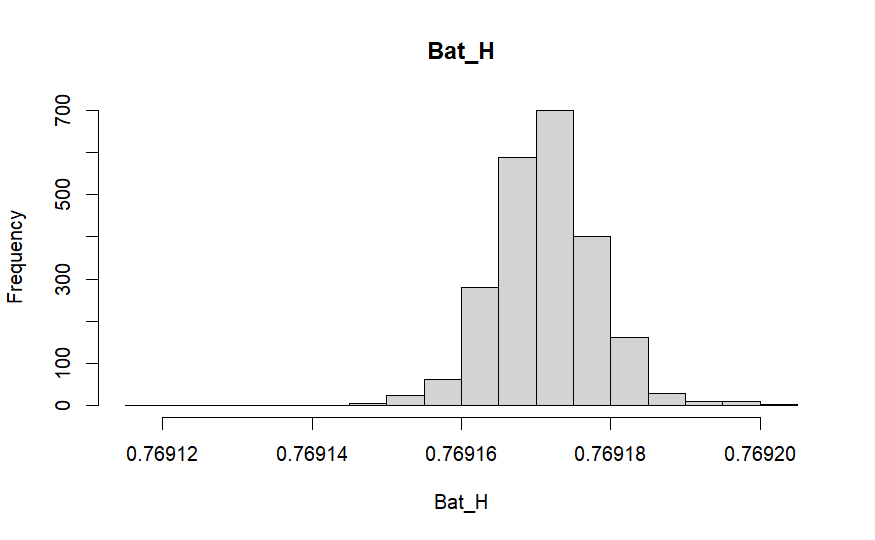

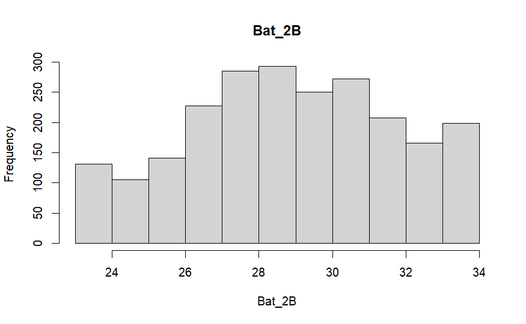

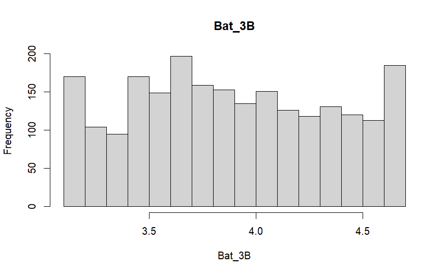

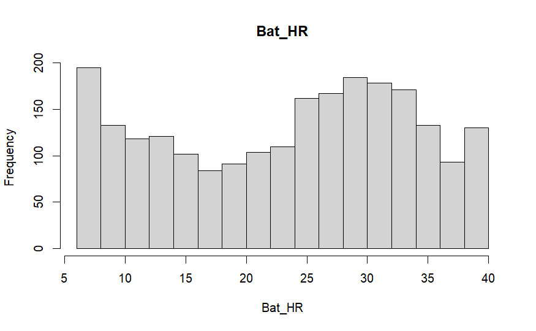

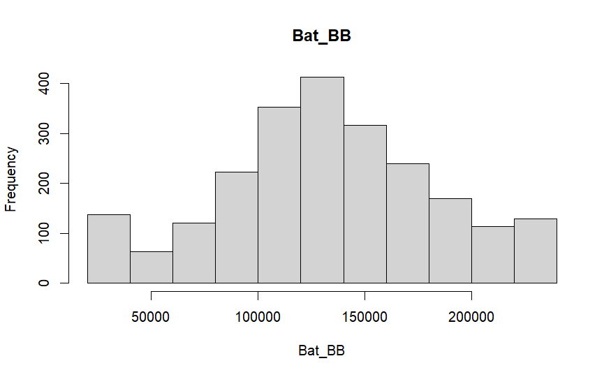

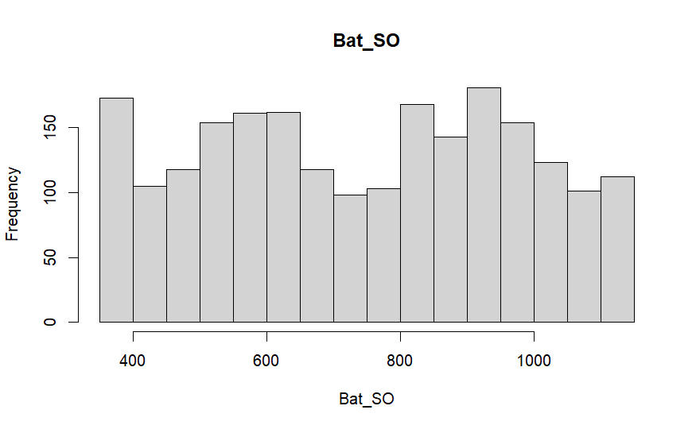

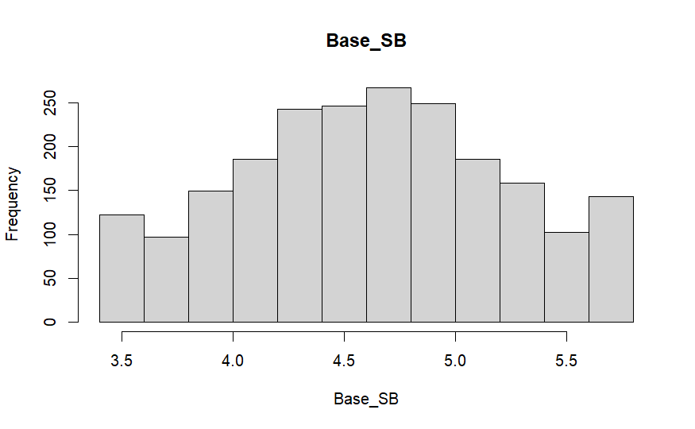

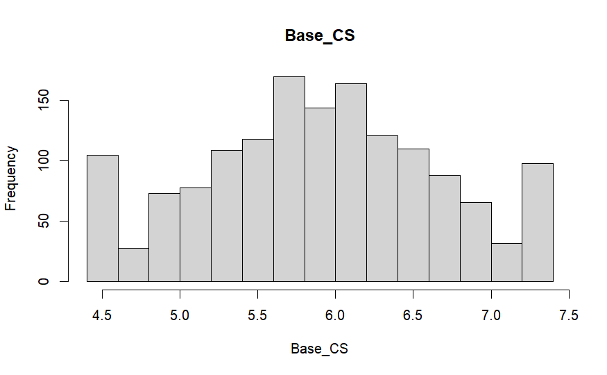

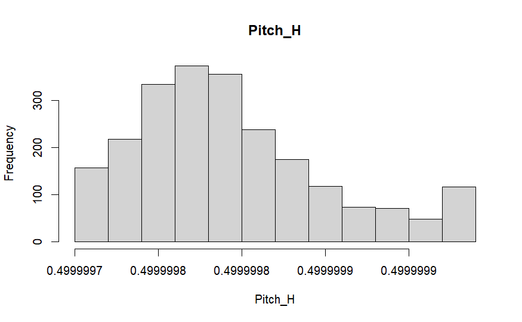

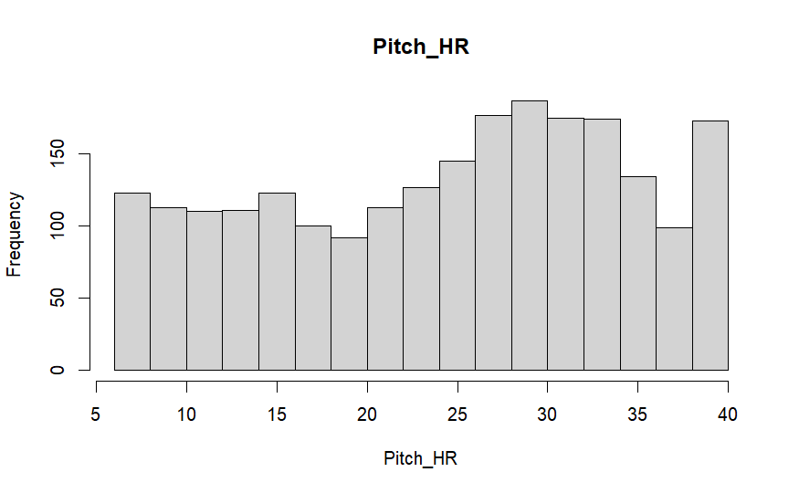

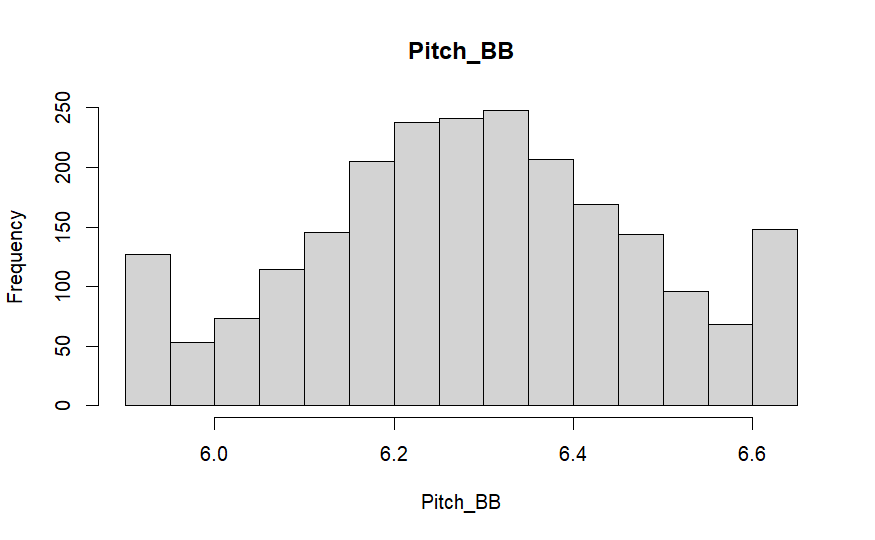

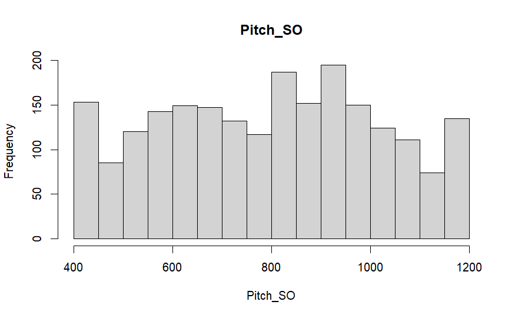

[2 more figures not shown]

```r
for (col_name in colnames(trainBC[-1])) {
  hist(trainBC[[col_name]], main = col_name, xlab = col_name)
}
```

For non-winsorized data, It looks like if outliers can be removed or dealt with, only Pitch_H and Field_E would be needed. For winsorized data, every column was transformed, implying a decrease in normality.

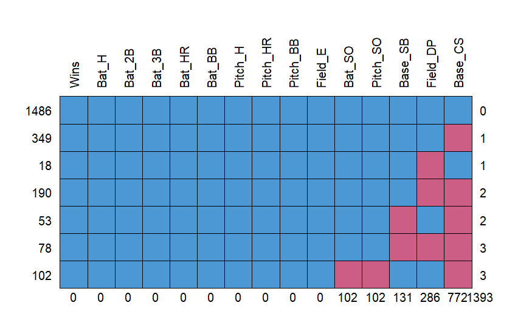

```r
pattern <- md.pattern(train_cleaned, rotate.names = TRUE)
```

```r
pattern <- as.data.frame(pattern)

pattern
```

|  | Wins | Bat_H | Bat_2B | Bat_3B | Bat_HR | Bat_BB | Pitch_H | Pitch_HR | Pitch_BB | Field_E | Bat_SO | Pitch_SO | Base_SB | Field_DP | Base_CS | V16 |
| --- | --- | --- | --- | --- | --- | --- | --- | --- | --- | --- | --- | --- | --- | --- | --- | --- |
| 1486 | 1 | 1 | 1 | 1 | 1 | 1 | 1 | 1 | 1 | 1 | 1 | 1 | 1 | 1 | 1 | 0 |
| 349 | 1 | 1 | 1 | 1 | 1 | 1 | 1 | 1 | 1 | 1 | 1 | 1 | 1 | 1 | 0 | 1 |
| 18 | 1 | 1 | 1 | 1 | 1 | 1 | 1 | 1 | 1 | 1 | 1 | 1 | 1 | 0 | 1 | 1 |
| 190 | 1 | 1 | 1 | 1 | 1 | 1 | 1 | 1 | 1 | 1 | 1 | 1 | 1 | 0 | 0 | 2 |
| 53 | 1 | 1 | 1 | 1 | 1 | 1 | 1 | 1 | 1 | 1 | 1 | 1 | 0 | 1 | 0 | 2 |
| 78 | 1 | 1 | 1 | 1 | 1 | 1 | 1 | 1 | 1 | 1 | 1 | 1 | 0 | 0 | 0 | 3 |
| 102 | 1 | 1 | 1 | 1 | 1 | 1 | 1 | 1 | 1 | 1 | 0 | 0 | 1 | 1 | 0 | 3 |
|  | 0 | 0 | 0 | 0 | 0 | 0 | 0 | 0 | 0 | 0 | 102 | 102 | 131 | 286 | 772 | 1393 |

Batting_HBP is missing for almost all observations and should be removed. There were no samples that had at least 50% of the variables missing, leading to the conclusion of keeping all observations. Only a maximum of 3 features are missing at a time. 3 features out of 14 is less than 50% of the feature count for a sample, so no observations need to be replaced.

#norm.predict (imputes based on the “best value” determined by linear reg) #mice.impute.norm.boot (imputes by log reg with bootstrap aggregation, best for ) #norm.nob (imputes without accounting for parameter uncertainty, Bat_SO looks bad) #norm (univariate missing data by Bayesian linear reg - Pitch_SO and Field_DP look ok) #mpmm (imputes multivariate incomplete data that has relationships like polynomials) #cart (imputes based on regression trees - Bat_SO matches great)

Before changing variables used in prediction methods. The best methods that match are: Bat_SO - CART Norm - Pitch_SO and Field_DP Norm.nob - for any other than Bat_SO Mean - for Base_SB and Base_CS, Pitch_SO? Field_DP

```r
summary(train_imputed)
```

```
Class: mids
Number of multiple imputations:  5
Imputation methods:
    Wins    Bat_H   Bat_2B   Bat_3B   Bat_HR   Bat_BB   Bat_SO  Base_SB  Base_CS  Pitch_H Pitch_HR Pitch_BB
      ""       ""       ""       ""       ""       ""   "cart"   "mean"   "mean"       ""       ""       ""
Pitch_SO  Field_E Field_DP
  "mean"       ""   "mean"
PredictorMatrix:
       Wins Bat_H Bat_2B Bat_3B Bat_HR Bat_BB Bat_SO Base_SB Base_CS Pitch_H Pitch_HR Pitch_BB Pitch_SO Field_E
Wins      0     1      1      1      1      1      1       1       1       1        1        1        1       1
Bat_H     1     0      1      1      1      1      1       1       1       1        1        1        1       1
Bat_2B    1     1      0      1      1      1      1       1       1       1        1        1        1       1
Bat_3B    1     1      1      0      1      1      1       1       1       1        1        1        1       1
Bat_HR    1     1      1      1      0      1      1       1       1       1        1        1        1       1
Bat_BB    1     1      1      1      1      0      1       1       1       1        1        1        1       1
       Field_DP
Wins          1
Bat_H         1
Bat_2B        1
Bat_3B        1
Bat_HR        1
Bat_BB        1
```

|  | 1 | 2 | 3 | 4 | 5 |
| --- | --- | --- | --- | --- | --- |
| 77 | 432 | 565 | 377 | 583 | 551 |
| 78 | 1045 | 333 | 1119 | 541 | 1029 |
| 79 | 542 | 541 | 686 | 522 | 934 |
| 80 | 454 | 954 | 487 | 888 | 1233 |
| 81 | 1102 | 637 | 598 | 666 | 535 |
| 82 | 1118 | 1085 | 1044 | 1028 | 988 |
| 83 | 1055 | 522 | 530 | 551 | 930 |
| 175 | 1056 | 1037 | 1106 | 558 | 551 |
| 176 | 704 | 575 | 600 | 403 | 635 |
| 177 | 1045 | 1026 | 1061 | 1090 | 1094 |

[output cut: 92 more lines]

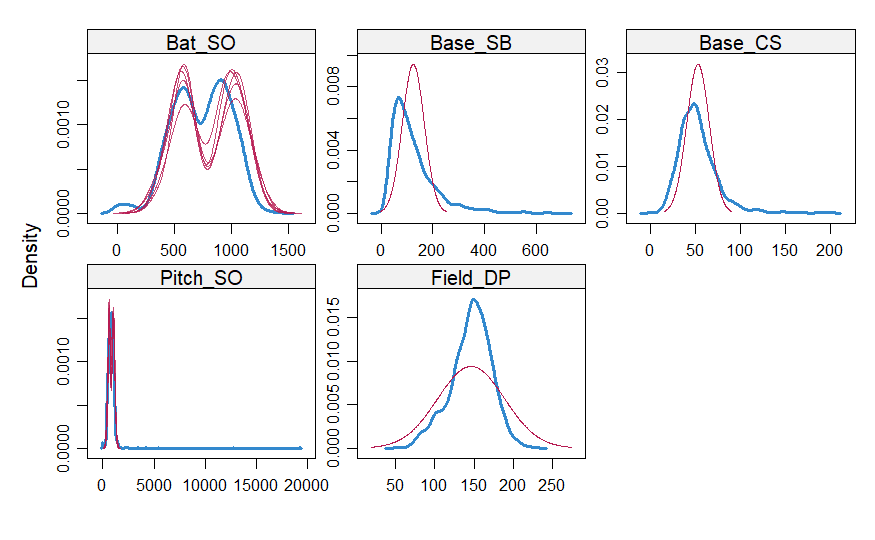

```r
densityplot(train_imputed)
```

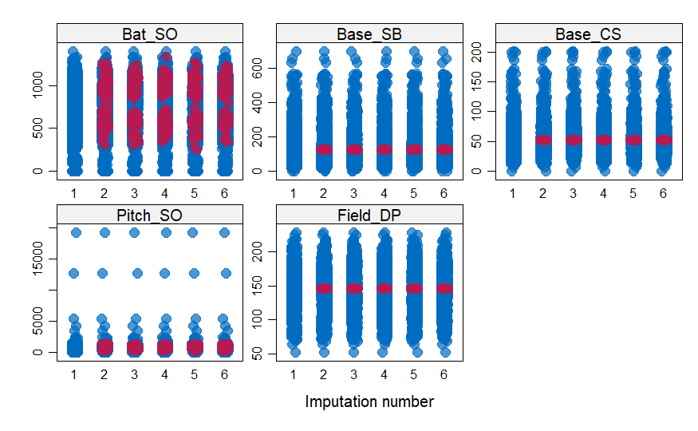

```r
stripplot(train_imputed, Bat_SO+Base_SB+Base_CS+Pitch_SO+Field_DP~.imp, pch=20, cex=2)
```

## Adding Ratios

1. TEAM_BATTING_H_TEAM_PITCHING_H_RATIO
2. TEAM_BATTING_HR_TEAM_PITCHING_HR_RATIO
3. TEAM_BATTING_BB_TEAM_PITCHING_BB_RATIO
4. TEAM_BATTING_SO_TEAM_PITCHING_SO_RATIO

```r
imputes_1 <- complete(train_imputed, 1)
imputes_2 <- complete(train_imputed, 2)
imputes_3 <- complete(train_imputed, 3)
imputes_4 <- complete(train_imputed, 4)
imputes_5 <- complete(train_imputed, 5)

imputed_ratios <- imputes_1 %>%
  mutate(Ratio_Bat_H_Pitch_H = Bat_H / Pitch_H,
         Ratio_Bat_HR_Pitch_HR = Bat_HR / Pitch_HR,
         Ratio_Bat_BB_Pitch_BB = Ratio_Bat_BB_Pitch_BB,
         Ratio_Bat_SO_Pitch_SO = Bat_SO / Pitch_SO
         )
```

[output not shown]

```r
train_done <- complete(train_imputed,1)

write_csv(train_done, "train_imputed.csv")
```

[figure not shown]